# Database Group Assignment

Group Members Jichi Ge [ge.jic@northeastern.edu] Wei Song [song.wei1@northeastern.edu] Yu Swe Zin Aung [yuswezinaung.y@northeastern.edu] Ziqi Fo [fo.z@northeastern.edu]

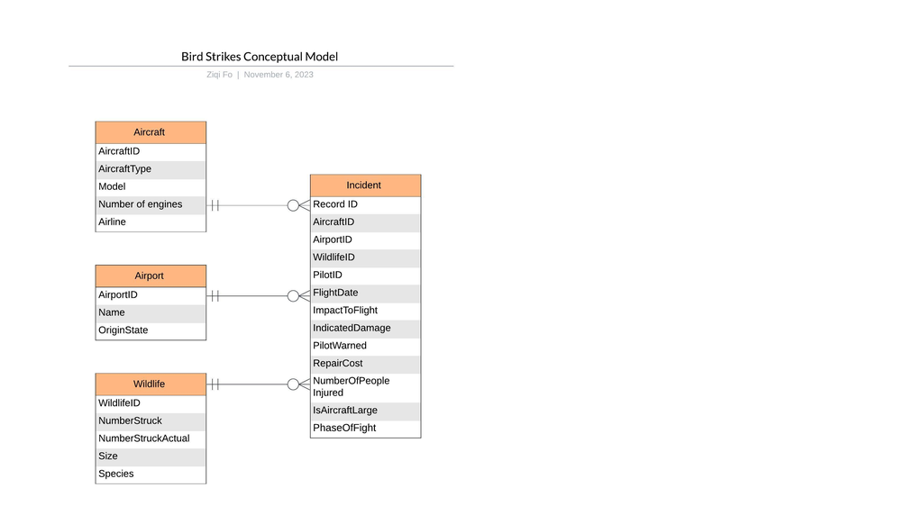

Bird Strikes Conceptual Model

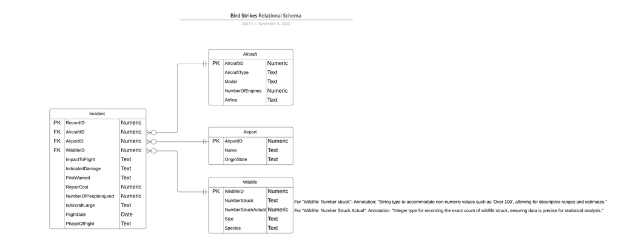

Bird Strikes Relational Schema

Read csv file

```r
library(DBI)
library(RMySQL)
library(dplyr)
```

```r
library(ggplot2)
library(RColorBrewer)


fpath = "E:/temp/Database_GroupProject_1/Database_GroupProject_1/"
dbFile = "BirdStrikesData.csv"
fullPath = paste0(fpath, dbFile)
birdStrikesData <- read.csv(fullPath)
```

```r
colnames(birdStrikesData)
```

```
##  [1] "Record.ID"
##  [2] "Aircraft..Type"
##  [3] "Airport..Name"
##  [4] "Altitude.bin"
##  [5] "Aircraft..Make.Model"
##  [6] "Wildlife..Number.struck"
##  [7] "Wildlife..Number.Struck.Actual"
##  [8] "Effect..Impact.to.flight"
##  [9] "FlightDate"
## [10] "Effect..Indicated.Damage"
## [11] "Aircraft..Number.of.engines."
## [12] "Aircraft..Airline.Operator"
## [13] "Origin.State"
## [14] "When..Phase.of.flight"
## [15] "Conditions..Precipitation"
## [16] "Remains.of.wildlife.collected."
## [17] "Remains.of.wildlife.sent.to.Smithsonian"
## [18] "Remarks"
## [19] "Wildlife..Size"
## [20] "Conditions..Sky"
## [21] "Wildlife..Species"
## [22] "Pilot.warned.of.birds.or.wildlife."
## [23] "Cost..Total.."
## [24] "Feet.above.ground"
## [25] "Number.of.people.injured"
## [26] "Is.Aircraft.Large."
```

Data from csv

```r
head(birdStrikesData)
```

|  | Record.ID | Aircraft..Type | Airport..Name | Altitude.bin | Aircraft..Make.Model | Wildlife..Number.struck | Wildlife..Number.Struck.Actual | Effect..Impact.to.flight | FlightDate | Effect..Indicated.Damage | Aircraft..Number.of.engines. | Aircraft..Airline.Operator | Origin.State | When..Phase.of.flight | Conditions..Precipitation | Remains.of.wildlife.collected. | Remains.of.wildlife.sent.to.Smithsonian | Remarks | Wildlife..Size | Conditions..Sky | Wildlife..Species | Pilot.warned.of.birds.or.wildlife. | Cost..Total.. | Feet.above.ground | Number.of.people.injured | Is.Aircraft.Large. |
| --- | --- | --- | --- | --- | --- | --- | --- | --- | --- | --- | --- | --- | --- | --- | --- | --- | --- | --- | --- | --- | --- | --- | --- | --- | --- | --- |
| 1 | 202152 | Airplane | LAGUARDIA NY | > 1000 ft | B-737-400 | Over 100 | 859 | Engine Shut Down | 11/23/2000 0:00 | Caused damage | 2 | US AIRWAYS* | New York | Climb | None | FALSE | FALSE | FLT 753. PILOT REPTD A HUNDRED BIRDS ON UNKN TYPE. #1 ENG WAS SHUT DOWN AND DIVERTED TO EWR. SLIGHT VIBRATION. A/C WAS OUT OF SVC FOR REPAIRS TO COWLING, FAN DUCT ACCOUSTIC PANEL. INGESTION. DENTED FA… | Medium | No Cloud | Unknown bird - medium | N | 30,736 | 1,500 | 0 | Yes |
| 2 | 208159 | Airplane | DALLAS/FORT WORTH INTL ARPT | < 1000 ft | MD-80 | Over 100 | 424 | None | 7/25/2001 0:00 | Caused damage | 2 | AMERICAN AIRLINES | Texas | Landing Roll | None | FALSE | FALSE | 102 CARCASSES FOUND. 1 LDG LIGHT ON NOSE GEAR WAS DAMAGED AND REPLACED. | Small | Some Cloud | Rock pigeon | Y | 0 | 0 | 0 | No |
| 3 | 207601 | Airplane | LAKEFRONT AIRPORT | < 1000 ft | C-500 | Over 100 | 261 | None | 9/14/2001 0:00 | No damage | 2 | BUSINESS | Louisiana | Approach | None | FALSE | FALSE | FLEW UNDER A VERY LARGE FLOCK OF BIRDS OVER APCH END OF RWY. NO DMG. JUST A LOT OF BIRD DROPPINGS ON WINDSCREEN. | Small | No Cloud | European starling | N | 0 | 50 | 0 | No |
| 4 | 215953 | Airplane | SEATTLE-TACOMA INTL | < 1000 ft | B-737-400 | Over 100 | 806 | Precautionary Landing | 9/5/2002 0:00 | No damage | 2 | ALASKA AIRLINES | Washington | Climb | None | TRUE | FALSE | NOTAM WARNING. 26 BIRDS HIT THE A/C, FORCING AN EMERGENCY LDG. 77 BIRDS WERE FOUND DEAD ON RWY/TWY WITH GRASSHOPPERS IN THEIR STOMACHS. SAFETY AREAS COULD NOT BE THOROUGHLY INSPCTD DURING 14 MINUTE SH… | Small | Some Cloud | European starling | Y | 0 | 50 | 0 | Yes |
| 5 | 219878 | Airplane | NORFOLK INTL | < 1000 ft | CL-RJ100/200 | Over 100 | 942 | None | 6/23/2003 0:00 | No damage | 2 | COMAIR AIRLINES | Virginia | Approach | None | FALSE | FALSE | NO DMG REPTD. | Small | No Cloud | European starling | N | 0 | 50 | 0 | No |
| 6 | 218432 | Airplane | GUAYAQUIL/S BOLIVAR | < 1000 ft | A-300 | Over 100 | 537 | None | 7/24/2003 0:00 | No damage | 2 | AMERICAN AIRLINES | N/A | Take-off run | None | FALSE | FALSE | NO DMG. BIRD REMAINS ON F/O WINDSCREEN. | Small | No Cloud | Unknown bird - small | N | 0 | 0 | 0 | No |

Number of Rows in csv file

```r
nrow(birdStrikesData)
```

```
## [1] 25558
```

remove row if aircraft type empty/null

```r
birdStrikesData <- birdStrikesData[!birdStrikesData$Aircraft..Type == "",]
```

remove row if Number of engines is not between 1 and 4

```r
birdStrikesData <- birdStrikesData[birdStrikesData$Aircraft..Number.of.engines. >= 1 &
                                   birdStrikesData$Aircraft..Number.of.engines. <= 4, ]
```

Number of Rows After Data Cleaning

```r
nrow(birdStrikesData)
```

```
## [1] 25194
```

Create AircraftID based on Aircraft columns

```r
birdStrikesData <- birdStrikesData %>%
  group_by(Aircraft..Type, Aircraft..Make.Model, Aircraft..Number.of.engines., Aircraft..Airline.Operator) %>%
  mutate(AircraftID=cur_group_id()) %>%
  ungroup
```

create AirportID based on Airport columns

```r
birdStrikesData <- birdStrikesData %>%
  group_by(Airport..Name, Origin.State) %>%
  mutate(AirportID=cur_group_id()) %>%
  ungroup
```

```r
birdStrikesData <- birdStrikesData %>%
  group_by(Wildlife..Number.struck, Wildlife..Number.Struck.Actual, Wildlife..Size, Wildlife..Species) %>%
  mutate(WildlifeID=cur_group_id()) %>%
  ungroup
```

```r
colnames(birdStrikesData)
```

```
##  [1] "Record.ID"
##  [2] "Aircraft..Type"
##  [3] "Airport..Name"
##  [4] "Altitude.bin"
##  [5] "Aircraft..Make.Model"
##  [6] "Wildlife..Number.struck"
##  [7] "Wildlife..Number.Struck.Actual"
##  [8] "Effect..Impact.to.flight"
##  [9] "FlightDate"
## [10] "Effect..Indicated.Damage"
## [11] "Aircraft..Number.of.engines."
## [12] "Aircraft..Airline.Operator"
## [13] "Origin.State"
## [14] "When..Phase.of.flight"
## [15] "Conditions..Precipitation"
## [16] "Remains.of.wildlife.collected."
## [17] "Remains.of.wildlife.sent.to.Smithsonian"
## [18] "Remarks"
## [19] "Wildlife..Size"
## [20] "Conditions..Sky"
## [21] "Wildlife..Species"
## [22] "Pilot.warned.of.birds.or.wildlife."
## [23] "Cost..Total.."
## [24] "Feet.above.ground"
## [25] "Number.of.people.injured"
## [26] "Is.Aircraft.Large."
## [27] "AircraftID"
## [28] "AirportID"
## [29] "WildlifeID"
```

Create Aircraft dataframe to import to db

```r
aircraftColumns = c('AircraftID', 'Aircraft..Type', 'Aircraft..Make.Model', 'Aircraft..Number.of.engines.', 'Aircraft..Airline.Operator')
AircraftDF <- birdStrikesData[aircraftColumns]
AircraftDF <- AircraftDF[!duplicated(AircraftDF), ]
```

```r
head(AircraftDF)
```

| AircraftID | Aircraft..Type | Aircraft..Make.Model | Aircraft..Number.of.engines. | Aircraft..Airline.Operator |
| --- | --- | --- | --- | --- |
| 246 | Airplane | B-737-400 | 2 | US AIRWAYS* |
| 1135 | Airplane | MD-80 | 2 | AMERICAN AIRLINES |
| 644 | Airplane | C-500 | 2 | BUSINESS |
| 238 | Airplane | B-737-400 | 2 | ALASKA AIRLINES |
| 734 | Airplane | CL-RJ100/200 | 2 | COMAIR AIRLINES |
| 5 | Airplane | A-300 | 2 | AMERICAN AIRLINES |

Create Airport dataframe to import to db

```r
airportColumns = c('AirportID', 'Airport..Name', 'Origin.State')
AirportDF <- birdStrikesData[airportColumns]
AirportDF <- AirportDF[!duplicated(AirportDF), ]
```

```r
head(AirportDF)
```

| AirportID | Airport..Name | Origin.State |
| --- | --- | --- |
| 527 | LAGUARDIA NY | New York |
| 208 | DALLAS/FORT WORTH INTL ARPT | Texas |
| 534 | LAKEFRONT AIRPORT | Louisiana |
| 907 | SEATTLE-TACOMA INTL | Washington |
| 710 | NORFOLK INTL | Virginia |
| 393 | GUAYAQUIL/S BOLIVAR | N/A |

Create Wildlife dataframe to import to db

```r
wildlifeColumns = c('WildlifeID', 'Wildlife..Number.struck', 'Wildlife..Number.Struck.Actual', 'Wildlife..Size', 'Wildlife..Species')
wildlifeDF <- birdStrikesData[wildlifeColumns]
wildlifeDF <- wildlifeDF[!duplicated(wildlifeDF), ]
```

```r
head(wildlifeDF)
```

| WildlifeID | Wildlife..Number.struck | Wildlife..Number.Struck.Actual | Wildlife..Size | Wildlife..Species |
| --- | --- | --- | --- | --- |
| 1226 | Over 100 | 859 | Medium | Unknown bird - medium |
| 1223 | Over 100 | 424 | Small | Rock pigeon |
| 1221 | Over 100 | 261 | Small | European starling |
| 1225 | Over 100 | 806 | Small | European starling |
| 1227 | Over 100 | 942 | Small | European starling |
| 1224 | Over 100 | 537 | Small | Unknown bird - small |

Create incident dataframe to import to db, we need to parse the flight date to R date data type with a format, so that we can change to MySQl compatible format

```r
incidentColumns = c('Record.ID', 'AircraftID', 'AirportID', 'WildlifeID', 'Effect..Impact.to.flight', 'FlightDate', 'Effect..Indicated.Damage',
                    'When..Phase.of.flight', 'Cost..Total..', 'Number.of.people.injured', 'Is.Aircraft.Large.', 'Pilot.warned.of.birds.or.wildlife.')
incidentDF <- birdStrikesData[incidentColumns]
incidentDF$FlightDate <- format(as.Date(incidentDF$FlightDate, format="%m/%d/%Y"), '%Y-%m-%d %H:%M:%S')
incidentDF <- incidentDF[!duplicated(incidentDF), ]
```

```r
head(incidentDF)
```

| Record.ID | AircraftID | AirportID | WildlifeID | Effect..Impact.to.flight | FlightDate | Effect..Indicated.Damage | When..Phase.of.flight | Cost..Total.. | Number.of.people.injured | Is.Aircraft.Large. | Pilot.warned.of.birds.or.wildlife. |
| --- | --- | --- | --- | --- | --- | --- | --- | --- | --- | --- | --- |
| 202152 | 246 | 527 | 1226 | Engine Shut Down | 2000-11-23 00:00:00 | Caused damage | Climb | 30,736 | 0 | Yes | N |
| 208159 | 1135 | 208 | 1223 | None | 2001-07-25 00:00:00 | Caused damage | Landing Roll | 0 | 0 | No | Y |
| 207601 | 644 | 534 | 1221 | None | 2001-09-14 00:00:00 | No damage | Approach | 0 | 0 | No | N |
| 215953 | 238 | 907 | 1225 | Precautionary Landing | 2002-09-05 00:00:00 | No damage | Climb | 0 | 0 | Yes | Y |
| 219878 | 734 | 710 | 1227 | None | 2003-06-23 00:00:00 | No damage | Approach | 0 | 0 | No | N |
| 218432 | 5 | 393 | 1224 | None | 2003-07-24 00:00:00 | No damage | Take-off run | 0 | 0 | No | N |

Initiate MySQL database connection with username and password

```r
dbcon <- dbConnect(RMySQL::MySQL(), username="newuser", password="password123456")
summary(dbcon)
```

```
## <MySQLConnection:0,0>
##   User:   newuser
##   Host:   localhost
##   Dbname:
##   Connection type: localhost via TCP/IP
##
## Results:
```

```sql
CREATE DATABASE IF NOT EXISTS birdstrikedb
```

```sql
USE birdstrikedb
```

```sql
DROP TABLE IF EXISTS Incident;
```

```sql
DROP TABLE IF EXISTS Aircraft;
```

```sql
DROP TABLE IF EXISTS Airport;
```

```sql
DROP TABLE IF EXISTS Wildlife;
```

```sql
CREATE TABLE IF NOT EXISTS Airport (
    AirportID INT,
    Name VARCHAR(255) NOT NULL,
    OriginState VARCHAR(255) NOT NULL,
    PRIMARY KEY(AirportID)
);
```

```sql
CREATE TABLE IF NOT EXISTS Wildlife (
    WildlifeID INT,
    NumberStruck VARCHAR(255) NOT NULL,
    NumberStruckActual INT NOT NULL,
    Size VARCHAR(255) NOT NULL,
    Species VARCHAR(255) NOT NULL,
     PRIMARY KEY (WildlifeID)
);
```

```sql
CREATE TABLE IF NOT EXISTS Aircraft (
    AircraftID INT,
    AircraftType VARCHAR(255) NOT NULL,
    Model VARCHAR(255) NOT NULL,
    NumberOfEngines INT NOT NULL CHECK (NumberOfEngines BETWEEN 1 AND 4),
    Airline VARCHAR(255) NOT NULL,
    PRIMARY KEY (AircraftID)
);
```

```sql
CREATE TABLE IF NOT EXISTS Incident (
    RecordID INT ,
    AircraftID INT,
    AirportID INT,
    WildlifeID INT,
    PhaseOfFlight TEXT CHECK(PhaseOfFlight IN ('Climb','Landing Roll','Approach','Take-off run','Descent','Taxi','Parked')),
    ImpactToFlight TEXT,
    IndicatedDamage TEXT,
    PilotWarned TEXT,
    RepairCost NUMERIC,
    NumberOfPeopleInjured INT,
    IsAircraftLarge BOOLEAN, -- Change data type
    FlightDate DATE,
    FOREIGN KEY (AircraftID) REFERENCES Aircraft(AircraftID),
    FOREIGN KEY (AirportID) REFERENCES Airport(AirportID),
    FOREIGN KEY (WildlifeID) REFERENCES Wildlife(WildlifeID),
    PRIMARY KEY (RecordID)
);
```

```r
dbListTables(dbcon)
```

```
## [1] "aircraft"                "airport"
## [3] "incident"                "numberofincidentcompare"
## [5] "wildlife"
```

Create Airport Data

Map dataframe columns to database column

```r
names(AirportDF)[names(AirportDF) == 'Airport..Name'] <- 'Name'
names(AirportDF)[names(AirportDF) == 'Origin.State'] <- 'OriginState'
```

Column name of AirPort DataFrame

```r
names(AirportDF)
```

```
## [1] "AirportID"   "Name"        "OriginState"
```

Write to each table

```r
dbWriteTable(dbcon, name="airport", value=AirportDF, append=TRUE, row.names=FALSE)
```

```
## [1] TRUE
```

Create aircraft Data Map dataframe columns to database column

```r
names(AircraftDF)[names(AircraftDF) == 'Aircraft..Type'] <- 'AircraftType'
names(AircraftDF)[names(AircraftDF) == 'Aircraft..Make.Model'] <- 'Model'
names(AircraftDF)[names(AircraftDF) == 'Aircraft..Number.of.engines.'] <- 'NumberOfEngines'
names(AircraftDF)[names(AircraftDF) == 'Aircraft..Airline.Operator'] <- 'Airline'

AircraftDF
```

| AircraftID | AircraftType | Model | NumberOfEngines | Airline |
| --- | --- | --- | --- | --- |
| 246 | Airplane | B-737-400 | 2 | US AIRWAYS* |
| 1135 | Airplane | MD-80 | 2 | AMERICAN AIRLINES |
| 644 | Airplane | C-500 | 2 | BUSINESS |
| 238 | Airplane | B-737-400 | 2 | ALASKA AIRLINES |
| 734 | Airplane | CL-RJ100/200 | 2 | COMAIR AIRLINES |
| 5 | Airplane | A-300 | 2 | AMERICAN AIRLINES |
| 1075 | Airplane | LEARJET-25 | 2 | BUSINESS |
| 67 | Airplane | A-320 | 2 | UNITED AIRLINES |
| 862 | Airplane | DC-9-30 | 2 | AIRTRAN AIRWAYS |
| 81 | Airplane | A-330 | 2 | AIRTOURS INTL |

[output cut: 1306 more lines]

Write to each table

```r
dbWriteTable(dbcon, name="aircraft", value=AircraftDF, append=TRUE, row.names=FALSE)
```

```
## [1] TRUE
```

Create wildlife Data

Map dataframe columns to database column

```r
names(wildlifeDF)[names(wildlifeDF) == 'Wildlife..Number.struck'] <- 'NumberStruck'
names(wildlifeDF)[names(wildlifeDF) == 'Wildlife..Number.Struck.Actual'] <- 'NumberStruckActual'
names(wildlifeDF)[names(wildlifeDF) == 'Wildlife..Size'] <- 'Size'
names(wildlifeDF)[names(wildlifeDF) == 'Wildlife..Species'] <- 'Species'
```

Write to each table

```r
dbWriteTable(dbcon, name="wildlife", value=wildlifeDF, append=TRUE, row.names=FALSE)
```

```
## [1] TRUE
```

Create incident Data Map dataframe columns to database column

```r
names(incidentDF)[names(incidentDF) == 'Record.ID'] <- 'RecordID'
names(incidentDF)[names(incidentDF) == 'Effect..Impact.to.flight'] <- 'ImpactToFlight'
names(incidentDF)[names(incidentDF) == 'FlightDate'] <- 'FlightDate'
names(incidentDF)[names(incidentDF) == 'Effect..Indicated.Damage'] <- 'IndicatedDamage'
names(incidentDF)[names(incidentDF) == 'When..Phase.of.flight'] <- 'PhaseOfFlight'
names(incidentDF)[names(incidentDF) == 'Cost..Total..'] <- 'RepairCost'
names(incidentDF)[names(incidentDF) == 'Number.of.people.injured'] <- 'NumberOfPeopleInjured'
names(incidentDF)[names(incidentDF) == 'Is.Aircraft.Large.'] <- 'IsAircraftLarge'
names(incidentDF)[names(incidentDF) == 'Pilot.warned.of.birds.or.wildlife.'] <- 'PilotWarned'
```

Column name of Incident DataFrame

```r
colnames(incidentDF)
```

```
##  [1] "RecordID"              "AircraftID"            "AirportID"
##  [4] "WildlifeID"            "ImpactToFlight"        "FlightDate"
##  [7] "IndicatedDamage"       "PhaseOfFlight"         "RepairCost"
## [10] "NumberOfPeopleInjured" "IsAircraftLarge"       "PilotWarned"
```

```r
head(incidentDF[order(incidentDF$RecordID),])
```

| RecordID | AircraftID | AirportID | WildlifeID | ImpactToFlight | FlightDate | IndicatedDamage | PhaseOfFlight | RepairCost | NumberOfPeopleInjured | IsAircraftLarge | PilotWarned |
| --- | --- | --- | --- | --- | --- | --- | --- | --- | --- | --- | --- |
| 200011 | 824 | 798 | 91 | None | 2000-04-06 00:00:00 | No damage | Landing Roll | 0 | 0 | No | Y |
| 200012 | 475 | 277 | 297 | None | 2000-04-10 00:00:00 | No damage | Landing Roll | 0 | 0 | No | Y |
| 200022 | 118 | 208 | 297 | None | 2000-02-28 00:00:00 | Caused damage | Approach | 0 | 0 | No | Y |
| 200023 | 235 | 773 | 116 | None | 2000-08-25 00:00:00 | No damage | Descent | 0 | 0 | Yes | N |
| 200028 | 151 | 233 | 44 | None | 2000-03-22 00:00:00 | No damage | Approach | 0 | 0 | No | Y |
| 200029 | 1286 | 567 | 192 | None | 2000-05-14 00:00:00 | No damage | Approach | 0 | 0 | No | Y |

Write to each table

```r
dbWriteTable(dbcon, name="incident", value=incidentDF, append=TRUE, row.names=FALSE)
```

```
## [1] TRUE
```

```sql
SELECT a.Airline, COUNT(*) AS NumIncidents
FROM Incident i
JOIN Aircraft a ON i.AircraftID = a.AircraftID
WHERE i.PhaseOfFlight IN ('Take-off', 'Climb')
GROUP BY a.Airline
ORDER BY NumIncidents DESC;
```

Displaying records 1 - 10

| Airline | NumIncidents |
| --- | --- |
| SOUTHWEST AIRLINES | 904 |
| BUSINESS | 672 |
| AMERICAN AIRLINES | 414 |
| DELTA AIR LINES | 242 |
| US AIRWAYS* | 179 |
| US AIRWAYS | 159 |
| AMERICAN EAGLE AIRLINES | 155 |
| SKYWEST AIRLINES | 134 |
| JETBLUE AIRWAYS | 106 |
| PRIVATELY OWNED | 105 |

#find the airports that had the most bird strike incidents

```sql
SELECT
    ap.Name AS AirportName,
    COUNT(inc.AirportID) AS NumberOfIncidents
FROM
    Incident inc
INNER JOIN
    Airport ap ON inc.AirportID = ap.AirportID
GROUP BY
    inc.AirportID
ORDER BY
    NumberOfIncidents DESC
LIMIT 10; -- Show top 10 airports with the most incidents
```

Displaying records 1 - 10

| AirportName | NumberOfIncidents |
| --- | --- |
| DALLAS/FORT WORTH INTL ARPT | 802 |
| SACRAMENTO INTL | 676 |
| SALT LAKE CITY INTL | 479 |
| DENVER INTL AIRPORT | 476 |
| KANSAS CITY INTL | 452 |
| PHILADELPHIA INTL | 442 |
| ORLANDO INTL | 408 |
| BALTIMORE WASH INTL | 401 |
| LOUISVILLE INTL ARPT | 394 |
| JOHN F KENNEDY INTL | 389 |

#find the number of bird strike incidents by year.

```sql
SELECT
    YEAR(FlightDate) AS Year,
    COUNT(*) AS NumberOfIncidents
FROM
    Incident
GROUP BY
    YEAR(FlightDate)
ORDER BY
    Year;
```

Displaying records 1 - 10

| Year | NumberOfIncidents |
| --- | --- |
| 2000 | 1349 |
| 2001 | 1194 |
| 2002 | 1642 |
| 2003 | 1566 |
| 2004 | 1690 |
| 2005 | 1851 |
| 2006 | 2148 |
| 2007 | 2288 |
| 2008 | 2242 |
| 2009 | 3206 |

```sql
DROP VIEW IF EXISTS NumberOfIncidentCompare;
```

```sql
CREATE VIEW NumberOfIncidentCompare
AS
SELECT Year, PhaseOfFlight, COUNT(*) AS NumberOfIncidents
              FROM (
                  SELECT YEAR(FlightDate) AS Year,
                         CASE
                             WHEN PhaseOfFlight IN ('Take-off run', 'Climb') THEN 'Take-off/Climb'
                             WHEN PhaseOfFlight IN ('Descent', 'Landing Roll', 'Approach') THEN 'Descent/Approach/Landing'
                             ELSE 'Other'
                         END AS PhaseOfFlight
                  FROM Incident
                  WHERE YEAR(FlightDate) BETWEEN 2008 and 2011
              ) AS BirdStrikeByYear
              GROUP BY Year, PhaseOfFlight
              ORDER BY Year, PhaseOfFlight;
```

```r
sql_query <- "SELECT * FROM NumberOfIncidentCompare;"
result <- dbGetQuery(dbcon, sql_query)
```

#We can see that in 2009, the number of incident increased a lot. From 2009 to 2011, the number of incident slowly decreased. There are more incidents happen in 2011 than in 2008 in all phase of the flight.

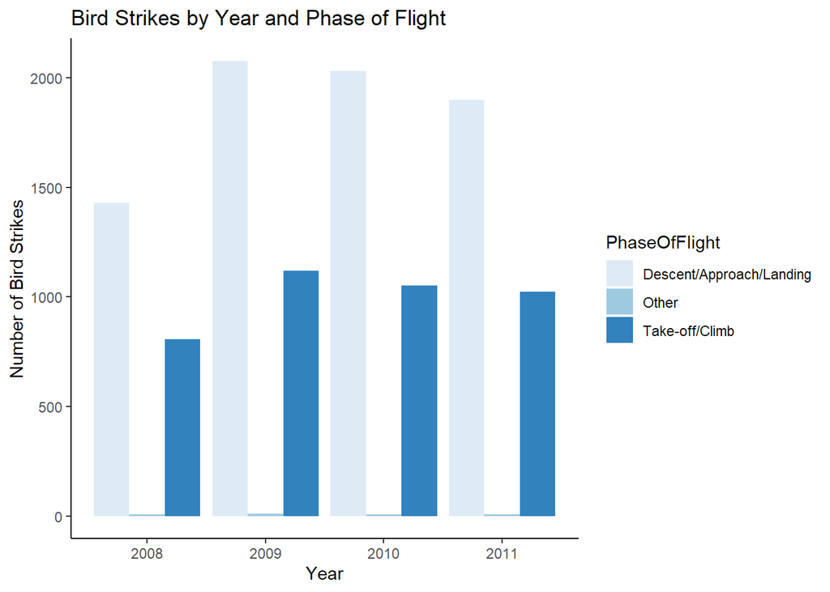

```r
custom_colors <- brewer.pal(n = 3, name = "Blues")

ggplot(result, aes(x = Year, y = NumberOfIncidents, fill = PhaseOfFlight)) +
  geom_bar(stat = "identity", position = "dodge") +
  labs(title = "Bird Strikes by Year and Phase of Flight",
       x = "Year",
       y = "Number of Bird Strikes") + theme_classic() +
  scale_fill_manual(values = custom_colors)
```

#It is almost doubled the chance of the flight getting hit by bird during Descent/Approach/Landing than during Take-off/Climb. The relative ratio of the phase of flight during incident is stable.

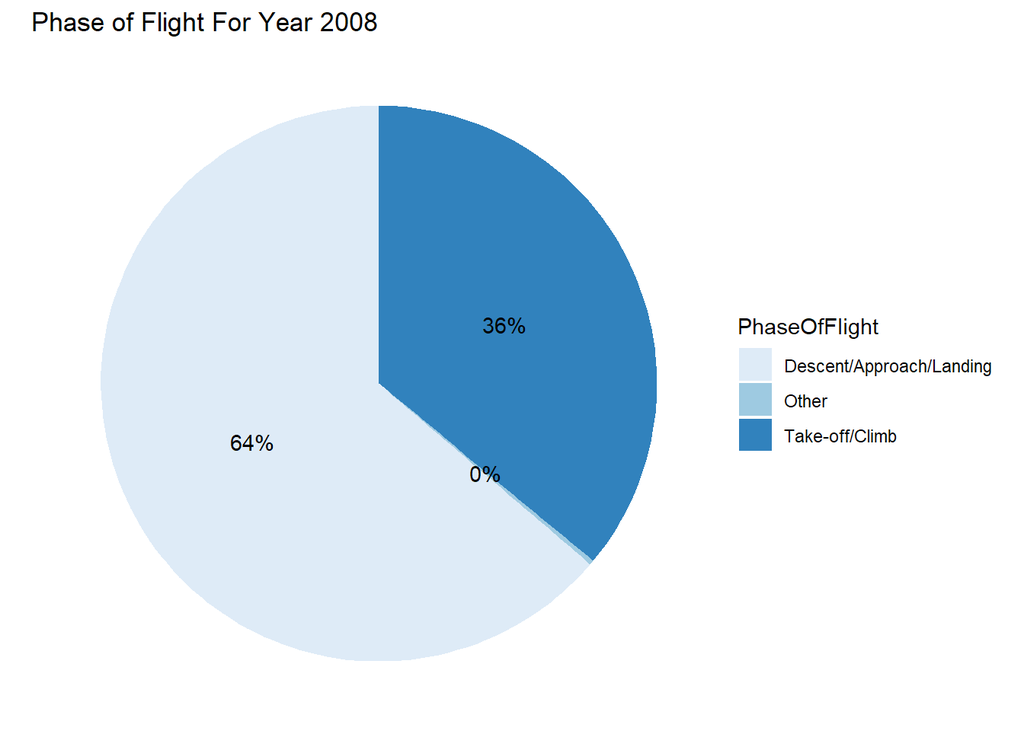

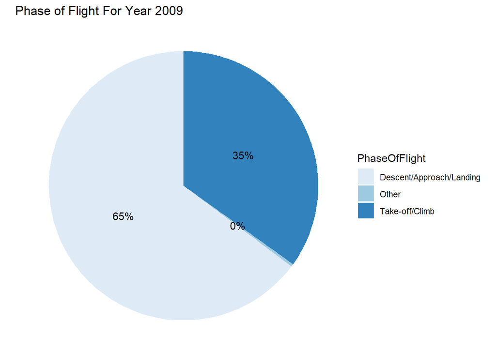

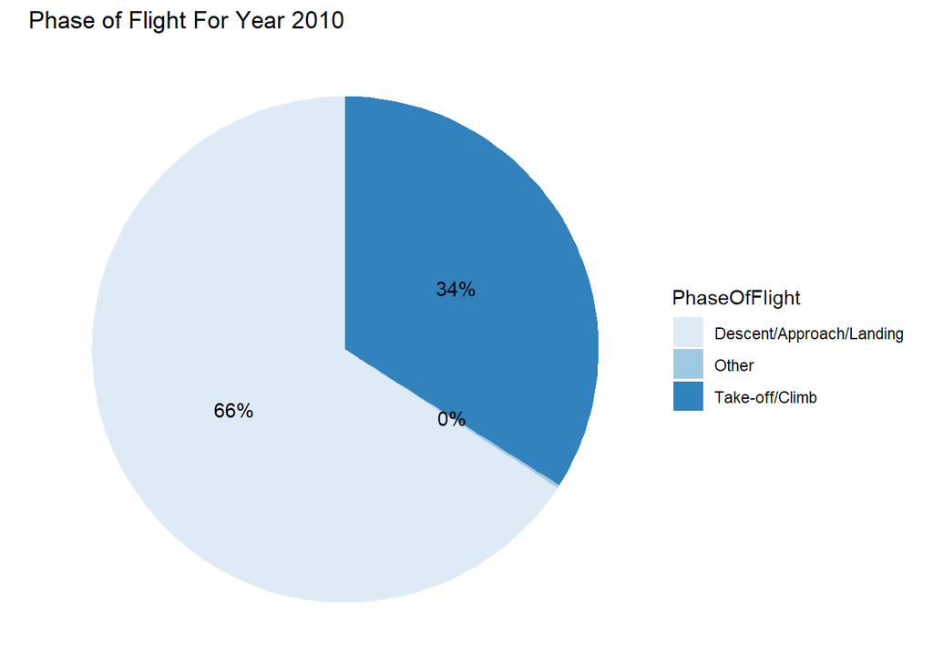

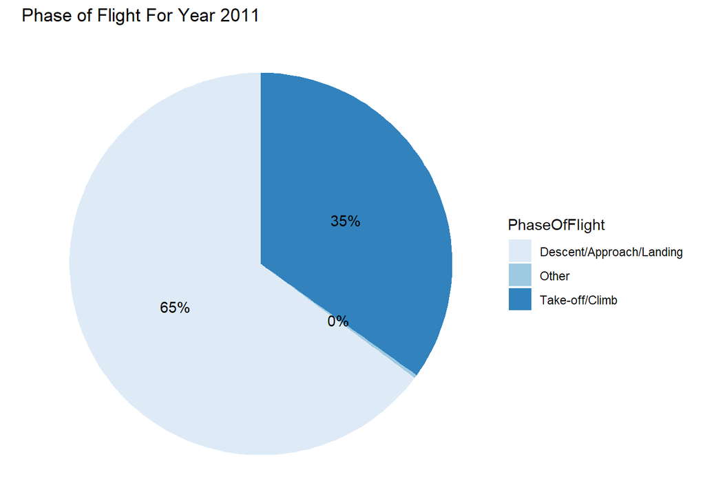

```r
unique_years <- unique(result$Year)
custom_colors <- brewer.pal(n = 3, name = "Blues")
for (year in unique_years) {
  year_data <- subset(result, Year == year)
  pie_chart <- ggplot(year_data, aes(x = "", y = NumberOfIncidents, fill = PhaseOfFlight)) +
    geom_bar(stat = "identity") +
    coord_polar(theta = "y") +
    theme_void() +
    geom_text(aes(label = scales::percent(NumberOfIncidents / sum(NumberOfIncidents))),
              position = position_stack(vjust = 0.5)) +
    labs(title = paste("Phase of Flight For Year", year))+ scale_fill_manual(values = custom_colors)



  print(pie_chart)

}
```

#There is an incident with an ID 200011

```sql
SELECT * FROM `incident`
WHERE `RecordID` = 200011;
```

1 records

| RecordID | AircraftID | AirportID | WildlifeID | PhaseOfFlight | ImpactToFlight | IndicatedDamage | PilotWarned | RepairCost | NumberOfPeopleInjured | IsAircraftLarge | FlightDate |
| --- | --- | --- | --- | --- | --- | --- | --- | --- | --- | --- | --- |
| 200011 | 824 | 798 | 91 | Landing Roll | None | No damage | Y | 0 | 0 | 0 | 2000-04-06 |

```sql
DROP PROCEDURE IF EXISTS `delete_bird_strike_by_id`;
```

#create a stored procedure that can delete with an input of RecordID from the table incident

```sql
CREATE PROCEDURE `delete_bird_strike_by_id`(IN RecordID INT)
BEGIN
     DELETE FROM `incident`
     WHERE `incident`.`RecordID` = RecordID;
END;
```

#call the stored procedure to delete the incident record with id 200011 from the table incident

```sql
CALL delete_bird_strike_by_id(200011);
```

#incident ID of 200011 is deleted from the table incident

```sql
SELECT * FROM `incident`
WHERE `RecordID` = 200011;
```

0 records

| RecordID | AircraftID | AirportID | WildlifeID | PhaseOfFlight | ImpactToFlight | IndicatedDamage | PilotWarned | RepairCost | NumberOfPeopleInjured | IsAircraftLarge | FlightDate |
| --- | --- | --- | --- | --- | --- | --- | --- | --- | --- | --- | --- |

```r
dbDisconnect(dbcon)
```

```
## [1] TRUE
```